# hyperparameter-tuning

Author

Chloe Rogozinski

Published

April 17, 2025

##Lab 8

## Data Import/Tidy/Transform

```r
#load required packages
library(tidyverse)
library(tidymodels)
library(powerjoin)
library(readr)
library(skimr)
library(visdat)
library(ggpubr)
```

## Read in data

```r
library(tidyverse)
library(powerjoin)

# List all attribute files
attribute_files <- list.files("data", pattern = "camels_.*\\.txt$", full.names = TRUE)

# Define a function to read each file with the correct delimiter
read_camels_file <- function(file) {
  read_delim(
    file,
    delim = ";",
    col_types = cols(.default = col_double(), gauge_id = col_character()),
    trim_ws = TRUE
  )
}

# Read each file and join by `gauge_id`
camels_list <- attribute_files %>%
  set_names(basename(.)) %>%
  map(read_camels_file)
# Merge all datasets
camels <- reduce(camels_list, power_full_join, by = "gauge_id")

# Preview structure
glimpse(camels)
```

```
Rows: 671
Columns: 58
$ gauge_id             <chr> "01013500", "01022500", "01030500", "01031500", "…
$ p_mean               <dbl> 3.126679, 3.608126, 3.274405, 3.522957, 3.323146,…
$ pet_mean             <dbl> 1.971555, 2.119256, 2.043594, 2.071324, 2.090024,…
$ p_seasonality        <dbl> 0.187940259, -0.114529586, 0.047358189, 0.1040905…
$ frac_snow            <dbl> 0.3134404, 0.2452590, 0.2770184, 0.2918365, 0.280…
$ aridity              <dbl> 0.6305587, 0.5873564, 0.6241114, 0.5879503, 0.628…
$ high_prec_freq       <dbl> 12.95, 20.55, 17.15, 18.90, 20.10, 13.50, 17.50, …
$ high_prec_dur        <dbl> 1.348958, 1.205279, 1.207746, 1.148936, 1.165217,…
$ high_prec_timing     <dbl> NA, NA, NA, NA, NA, NA, NA, NA, NA, NA, NA, NA, N…
$ low_prec_freq        <dbl> 202.20, 233.65, 215.60, 227.35, 235.90, 193.50, 2…
$ low_prec_dur         <dbl> 3.427119, 3.662226, 3.514262, 3.473644, 3.691706,…
$ low_prec_timing      <dbl> NA, NA, NA, NA, NA, NA, NA, NA, NA, NA, NA, NA, N…
$ geol_1st_class       <dbl> NA, NA, NA, NA, NA, NA, NA, NA, NA, NA, NA, NA, N…
```

[output cut: 45 more lines]

```r
#remove columns with missing values
camels_clean <- camels %>%
  select(where(~ mean(!is.na(.)) > 0.5))

#drop rows missing values
camels_clean <- camels_clean %>%
  drop_na(runoff_ratio)

camels_for_map <- camels_clean

camels_model <- camels_for_map %>%
  select(-gauge_id, -gauge_lat, -gauge_lon)



#check columns
camels_clean %>%
  select(where(is.character)) %>%
  names()
```

```
[1] "gauge_id"
```

## Data Splitting

```r
#set seed, split data, and extract sets
set.seed(123)

data_split <- initial_split(camels_model, prop = 0.8)

train_data <- training(data_split)
test_data  <- testing(data_split)
```

## Feature Engineering

```r
#create recipe
qmean_recipe <- recipe(q_mean ~ ., data = train_data) %>%
  step_normalize(all_predictors()) %>%
  step_corr(all_predictors(), threshold = 0.9) %>%
  step_nzv(all_predictors())
```

# 1. Build resamples

```r
#set seed and resample data
set.seed(123)
cv_folds <- vfold_cv(train_data, v = 10)
```

# 2. Build 3 Canidate Models

```r
#linear regression model
linear_model <- linear_reg() %>%
  set_engine("lm") %>%
  set_mode("regression")
```

```r
#Random forest model
rf_model <- rand_forest(trees = 500) %>%
  set_engine("ranger") %>%
  set_mode("regression")
```

```r
#Boosted tree model
xgb_model <- boost_tree(trees = 1000, learn_rate = 0.05) %>%
  set_engine("xgboost") %>%
  set_mode("regression")
```

# 3. Test the models

```r
#create named list of models
model_specs <- list(
  linear = linear_model,
  random_forest = rf_model,
  xgboost = xgb_model
)

#create workflow set
model_workflows <- workflow_set(
  preproc = list(qmean = qmean_recipe),
  models = model_specs
)
#fit the workflows
set.seed(123)
model_results <- model_workflows %>%
  workflow_map(resamples = cv_folds, verbose = TRUE)
```

```
i   No tuning parameters. `fit_resamples()` will be attempted
```

```
i 1 of 3 resampling: qmean_linear
```

```
✔ 1 of 3 resampling: qmean_linear (2.1s)
```

```
i   No tuning parameters. `fit_resamples()` will be attempted
```

```
i 2 of 3 resampling: qmean_random_forest
```

```
✔ 2 of 3 resampling: qmean_random_forest (7s)
```

```
i   No tuning parameters. `fit_resamples()` will be attempted
```

```
i 3 of 3 resampling: qmean_xgboost
```

```
✔ 3 of 3 resampling: qmean_xgboost (23.3s)
```

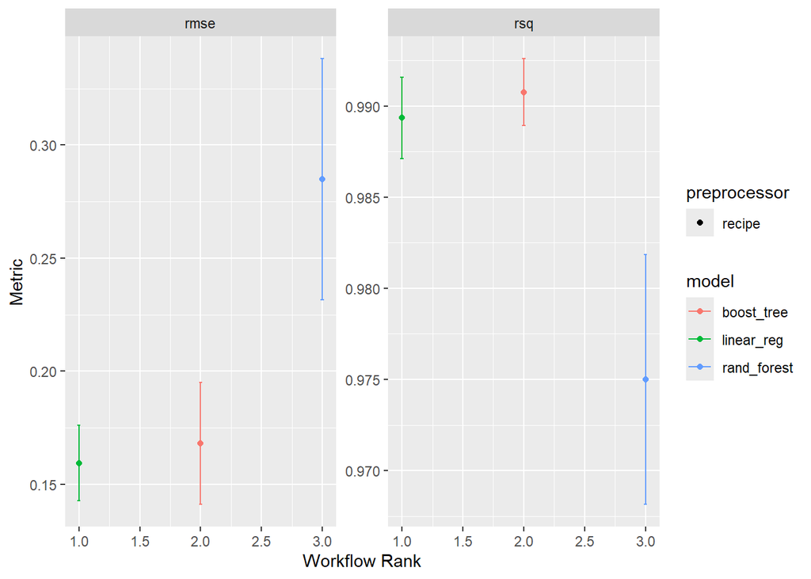

```r
#vizualize
autoplot(model_results)
```

# 4. Model Section

## Model Tuning

#1 Build a model

```r
rf_tune_model <- rand_forest(
  mtry = tune(),
  min_n = tune(),
  trees = 500
) %>%
  set_engine("ranger") %>%
  set_mode("regression")
```

#2 Create a Workflow

```r
rf_tune_workflow <- workflow() %>%
  add_model(rf_tune_model) %>%
  add_recipe(qmean_recipe)
```

#3 Check the Tunable Values

```r
#extract parameters
dials <- extract_parameter_set_dials(rf_tune_workflow)

#view the tuning parameters
dials$object
```

```
[[1]]
# Randomly Selected Predictors (quantitative)
Range: [1, ?]

[[2]]
Minimal Node Size (quantitative)
Range: [2, 40]
```

#4. Define the Search Space

```r
#finalize the parameter
dials_final <- finalize(dials, train_data)

#create grid
my.grid <- grid_space_filling(
  dials_final,
  size = 25
)
```

#5 Tune the Model

```r
model_params <- tune_grid(
  rf_tune_workflow,
  resamples = cv_folds,
  grid = my.grid,
  metrics = metric_set(rmse, rsq, mae),
  control = control_grid(save_pred = TRUE)
)
```

```
→ A | warning: 45 columns were requested but there were 44 predictors in the data. 44 will be used.
```

```
There were issues with some computations   A: x1
```

```
→ B | warning: 47 columns were requested but there were 44 predictors in the data. 44 will be used.
```

[output not shown]

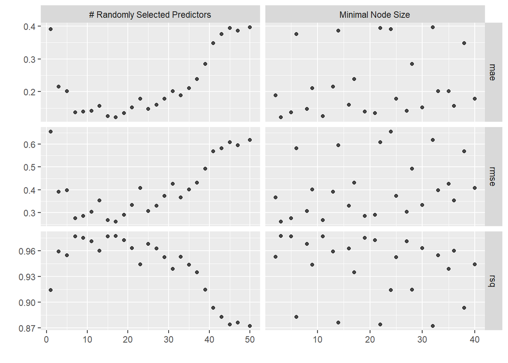

```r
autoplot(model_params)
```

#Answer:It looks like models with lower mtry values performed best — they had the lowest error and highest R². Performance dropped as mtry increased beyond ~10–15. min_n didn’t show a clear pattern, which suggests it wasn’t as influential for this dataset.

#6. Check the skill of the tuned model

```r
#collect metrics
collect_metrics(model_params)
```

```
# A tibble: 75 × 8
    mtry min_n .metric .estimator  mean     n std_err .config
   <int> <int> <chr>   <chr>      <dbl> <int>   <dbl> <chr>
 1     1    24 mae     standard   0.391    10 0.0171  Preprocessor1_Model01
 2     1    24 rmse    standard   0.654    10 0.0488  Preprocessor1_Model01
 3     1    24 rsq     standard   0.914    10 0.00969 Preprocessor1_Model01
 4     3    13 mae     standard   0.216    10 0.0149  Preprocessor1_Model02
 5     3    13 rmse    standard   0.392    10 0.0409  Preprocessor1_Model02
 6     3    13 rsq     standard   0.959    10 0.00644 Preprocessor1_Model02
 7     5    33 mae     standard   0.201    10 0.0151  Preprocessor1_Model03
 8     5    33 rmse    standard   0.398    10 0.0420  Preprocessor1_Model03
 9     5    33 rsq     standard   0.955    10 0.00714 Preprocessor1_Model03
10     7     5 mae     standard   0.137    10 0.0113  Preprocessor1_Model04
# ℹ 65 more rows
```

```r
show_best(model_params, metric = "mae")
```

```
# A tibble: 5 × 8
   mtry min_n .metric .estimator  mean     n std_err .config
  <int> <int> <chr>   <chr>      <dbl> <int>   <dbl> <chr>
1    17     3 mae     standard   0.122    10 0.00868 Preprocessor1_Model09
2    15    11 mae     standard   0.125    10 0.00922 Preprocessor1_Model08
3    19    21 mae     standard   0.135    10 0.00888 Preprocessor1_Model10
4     7     5 mae     standard   0.137    10 0.0113  Preprocessor1_Model04
5     9    19 mae     standard   0.140    10 0.00994 Preprocessor1_Model05
```

```r
hp_best <- select_best(model_params, metric = "mae")
```

#7. Finalizing the model

```r
#finalize and fit the model
final_rf_workflow <- finalize_workflow(rf_tune_workflow, hp_best)

final_rf_fit <- fit(final_rf_workflow, data = train_data)
```

## Final Model Verification

```r
#final fit
final_fit <- last_fit(
  final_rf_workflow,
  split = data_split
)

#evaluate
collect_metrics(final_fit)
```

```
# A tibble: 2 × 4
  .metric .estimator .estimate .config
  <chr>   <chr>          <dbl> <chr>
1 rmse    standard       0.198 Preprocessor1_Model1
2 rsq     standard       0.982 Preprocessor1_Model1
```

#answer: The final model performed really well on the test set, with low RMSE and high R². This means the predictions were close to the actual values and the model explained nearly all the variance in q_mean. The performance is consistent with training, so the model generalized well.

```r
final_preds <- collect_predictions(final_fit)

final_fit <- last_fit(
  final_rf_workflow,
  split = data_split
)
```

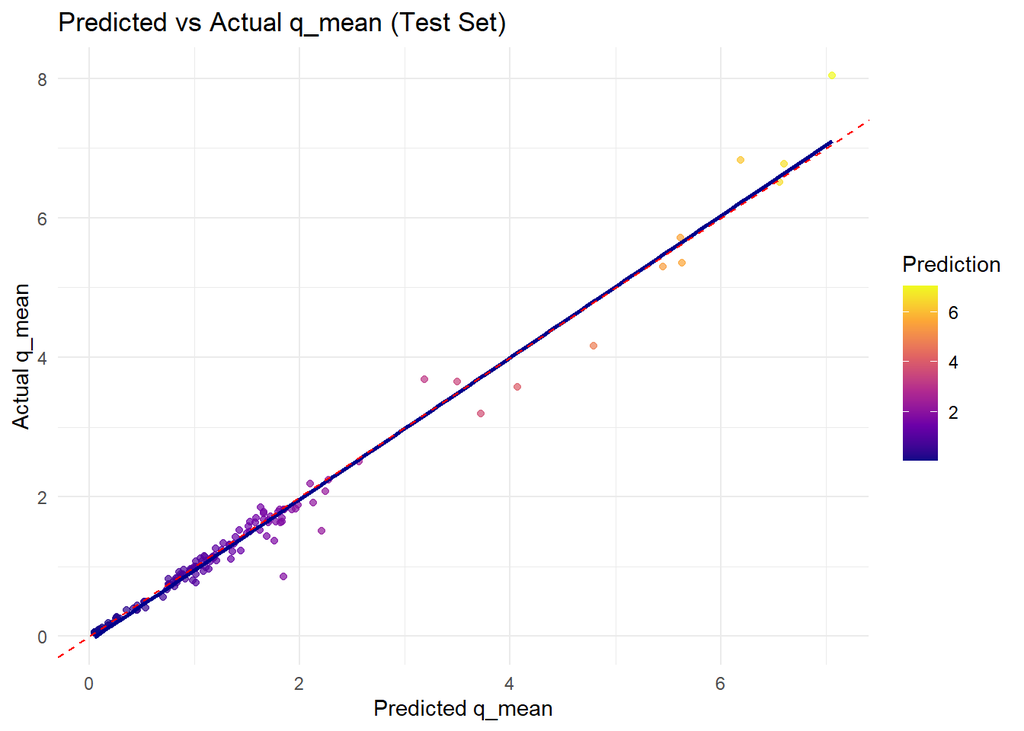

```r
#ggplot
ggplot(final_preds, aes(x = .pred, y = q_mean)) +
  geom_point(aes(color = .pred), alpha = 0.7) +
  geom_smooth(method = "lm", se = FALSE, color = "darkblue") +
  geom_abline(intercept = 0, slope = 1, linetype = "dashed", color = "red") +
  scale_color_viridis_c(option = "C") +
  labs(
    title = "Predicted vs Actual q_mean (Test Set)",
    x = "Predicted q_mean",
    y = "Actual q_mean",
    color = "Prediction"
  ) +
  theme_minimal()
```

## Building a Map

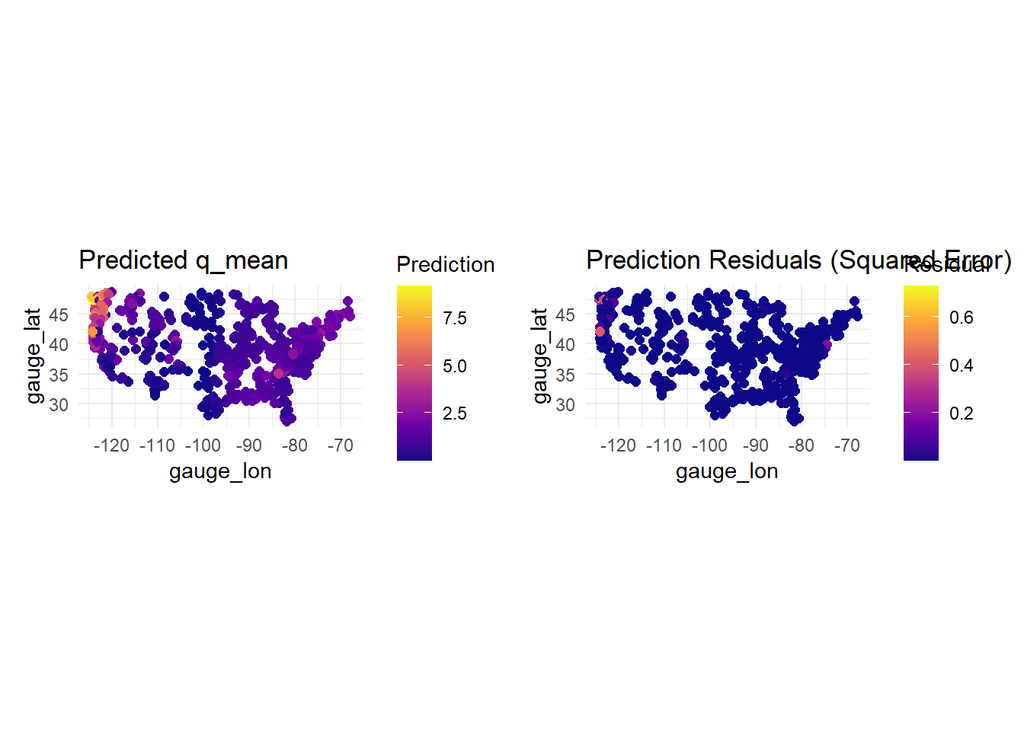

```r
#fit final model to cleaned data
full_fit <- fit(final_rf_workflow, data = camels_clean)

#predict
library(broom)

camels_aug <- augment(full_fit, new_data = camels_clean)

#add residuals
camels_aug <- camels_aug %>%
  mutate(
    residual = (.pred - q_mean)^2
  )

#create maps

library(ggplot2)
library(patchwork)

#prediction map
pred_map <- ggplot(camels_aug, aes(x = gauge_lon, y = gauge_lat, color = .pred)) +
  geom_point(size = 2) +
  scale_color_viridis_c(option = "C") +
  labs(title = "Predicted q_mean", color = "Prediction") +
  coord_fixed(1.3) +
  theme_minimal()

#residual map
resid_map <- ggplot(camels_aug, aes(x = gauge_lon, y = gauge_lat, color = residual)) +
  geom_point(size = 2) +
  scale_color_viridis_c(option = "C") +
  labs(title = "Prediction Residuals (Squared Error)", color = "Residual") +
  coord_fixed(1.3) +
  theme_minimal()

#combine
pred_map + resid_map
```